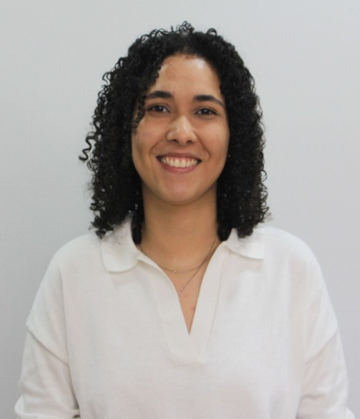

# Gabriela Díaz Porto

Student of Applied Statistics’ Master at Universidad del Norte, Barranquilla

[LinkedIn](https://linkedin.com) [Github](https://github/gabbdiazp)

# **About**

I am currently a middle school math teacher at [Marymount School](https://www.marymountbq.edu.co/web/) (Barranquilla), with three years of teaching experience. I am passionate about helping students truly understand the world of numbers. I earned my Bachelor’s degree in Mathematics from Universidad del Norte, where I developed a strong interest in algebra and group theory. Since 2023, I have been pursuing a Master’s degree in [Applied Statistics](https://www.uninorte.edu.co/web/maestria-en-estadistica-aplicada) at Universidad del Norte, aiming to deepen my knowledge in biostatistics and machine learning.

# **Education**

1. ITSA, Barranquilla - 2016  
   *Technician in Graphic Design*
2. Universidad del Norte, Barranquilla - 2021  
   *Mathematics*
3. Universidad del Norte, Barranquilla - In progress  
   *Master in Applied Statistics*

# **Honors and awards**

1. “Ser pilo paga” Scholarship - 3rd Edition.
2. Recognition for participation in the Fifth Winter School of Mathematics in Oaxaca from November 18 to 22, 2019.
3. Honorable mention for good academic performance in the Mathematics program at the Universidad del Norte in the 2020-10 semester.
4. “Julio Muvdi” Scholarship for Graduate Programs, Universidad del Norte.

# **Publications**

1. Diaz-Porto, G.; Gutierrez, I.; Torres-Grandisson, A. The t-Graphs over Finitely Generated Groups and the Minkowski Metric. [Mathematics](https://www.mdpi.com/2227-7390/10/17/3030) 2022, 10, 3030.